# Classification Trees

## Excercise 10

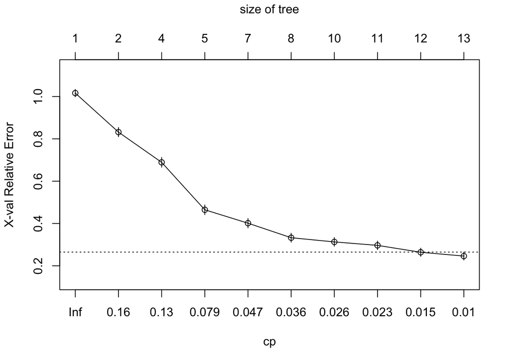

```r
plotcp(tree_big) #plots the cp parameter, which is the node purity
```

```r
printcp(tree_big)
```

```
##
## Classification tree:
## rpart(formula = class ~ ., data = land)
##
## Variables actually used in tree construction:
##  [1] BordLngth    BordLngth_40 Bright_100   Mean_G_40    Mean_NIR_100
##  [6] Mean_R       NDVI         NDVI_40      SD_NIR       ShpIndx_100
##
## Root node error: 553/675 = 0.81926
##
## n= 675
##
##          CP nsplit rel error  xerror     xstd
## 1  0.200723      0   1.00000 1.01627 0.017540
## 2  0.128391      1   0.79928 0.83183 0.021889
## 3  0.126582      3   0.54250 0.68897 0.023295
## 4  0.048825      4   0.41591 0.46474 0.022813
## 5  0.045208      6   0.31826 0.40145 0.022072
## 6  0.028029      7   0.27306 0.33273 0.020921
## 7  0.023508      9   0.21700 0.31284 0.020512
## 8  0.021700     10   0.19349 0.29656 0.020149
## 9  0.010850     11   0.17179 0.26401 0.019343
## 10 0.010000     12   0.16094 0.24593 0.018845
```

From the above plot, I would pick a cp parameter of 0.015.

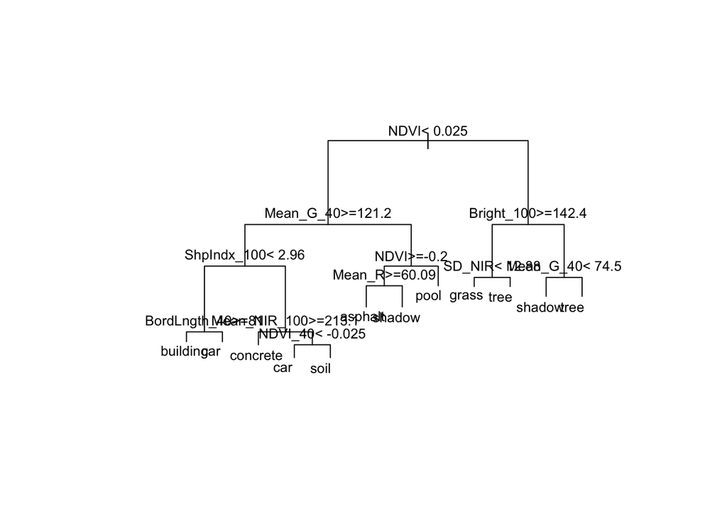

```r
tree_big_prune <- rpart(class ~ ., land, cp = 0.015)
plot(tree_big_prune, margin = 0.2)
text(tree_big_prune, cex = 0.8)
```

```r
tree_big$variable.importance
```

```
##         NDVI      NDVI_40      NDVI_60       Mean_G    Bright_40
##   130.071605   129.167673   124.216574   114.273292   106.956779
##    Mean_G_40      NDVI_80     NDVI_100     NDVI_120 Mean_NIR_100
##    90.467571    80.469919    76.139699    71.448628    70.288176
## Mean_NIR_120       Mean_R  Mean_NIR_40   Mean_G_100       Bright
##    67.882905    62.655931    62.371610    61.420513    60.697044
##     Mean_NIR    Mean_G_60  ShpIndx_100    Mean_G_80   Bright_100
##    55.543970    54.469185    53.962663    52.236842    48.416406
##  ShpIndx_120   Bright_120    Bright_80  BrdIndx_100  Mean_NIR_80
##    46.519537    45.443469    45.018763    42.797974    42.470531
##   ShpIndx_80  ShpIndx_140  Compact_100  Mean_NIR_60    BordLngth
##    42.425817    42.053661    40.192880    29.098990    27.333813
##    Mean_R_40   Mean_R_100   Mean_R_120 Mean_NIR_140   Mean_R_140
##    25.465537    25.412374    24.893754    24.375134    24.375134
##         Area         SD_G BordLngth_40      Area_40       SD_NIR
##    23.218161    21.264209    19.493877    17.200480    16.675167
##      Area_60         SD_R   Mean_G_120   Mean_G_140        GLCM2
##    14.907082    14.173892    10.523077    10.523077     9.457778
##   SD_NIR_120      ShpIndx      BrdIndx    SD_NIR_60     SD_R_140
##     8.106667     8.106667     7.431111     6.670067     6.670067
##      SD_R_60
##     6.670067
```

Now, there are only 12 terminal nodes and we are only using 9 predictors. The most important predictors still remain the same.

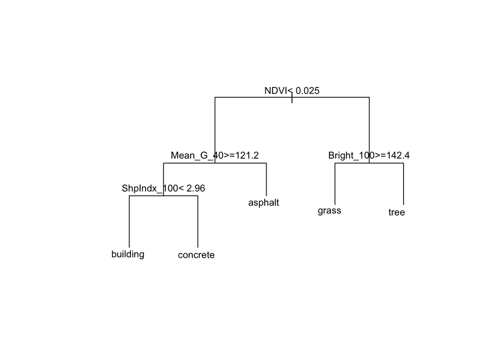

```r
tree_big_prune_ex <- rpart(class ~ ., land, cp = 0.079)
plot(tree_big_prune_ex, margin = 0.2)
text(tree_big_prune_ex, cex = 0.8)
```

We can see that with a higher cp cutoff, the tree changes a lot.

## Excercise 11

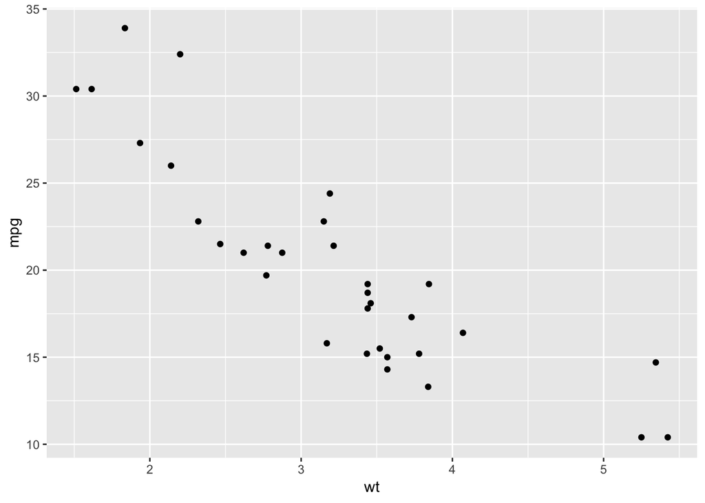

```r
data(mtcars)
?mtcars
ggplot(mtcars, aes(x = wt, y = mpg)) +
    geom_point()
```

## 11a)

```r
tree_mpg <- rpart(mpg ~ wt, mtcars)
```

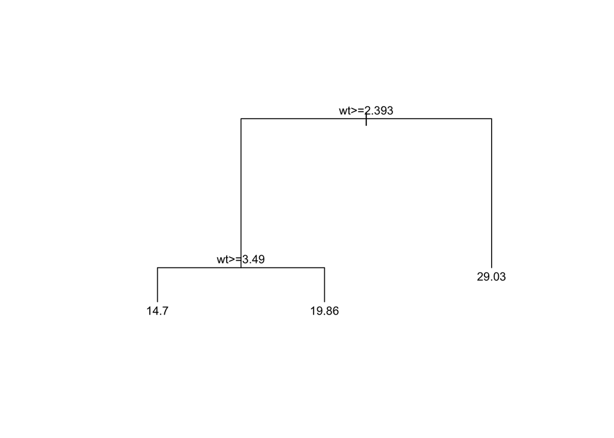

```r
plot(tree_mpg, margin = 0.2)
text(tree_mpg, cex = 0.8)
```

wt: 1 = mpg 29. wt:3 = mpg = 19.8 wt:5 = mpg = 14.7

## 11c)

This tree has 3 possible predictions for MPG.

## 11d)

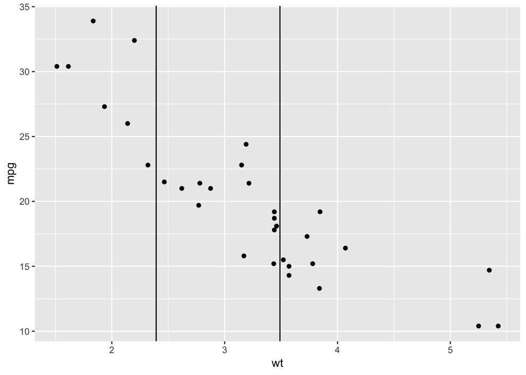

```r
ggplot(mtcars, aes(x = wt, y = mpg)) +
    geom_point() +
    geom_vline(xintercept = 2.393) +
    geom_vline(xintercept = 3.49)
```

## Excercise 12

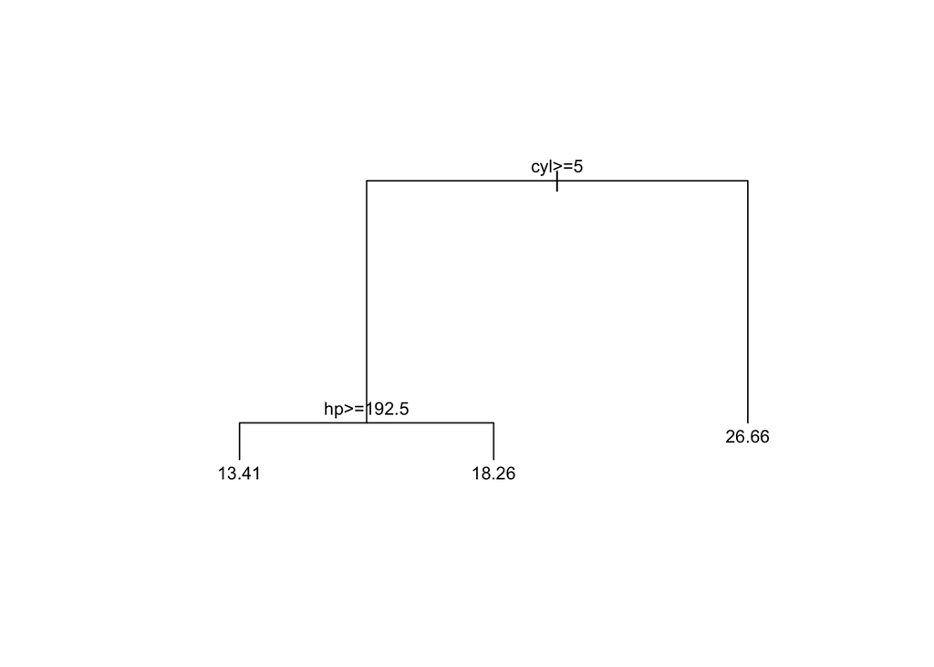

```r
tree_mpg_all <- rpart(mpg ~ ., mtcars)
plot(tree_mpg_all, margin = 0.2)
text(tree_mpg_all, cex = 0.8)
```